# IGRAresults

Hannah Rickman

2023-02-08

```r
library(tidyverse)
library(rlang)
library(here)
library(lubridate)
library(table1)
library(epiR)
library(patchwork)
library(cowplot)
library(janitor)
library(flextable)
library(broom)
library(cmdstanr)
library(tidybayes)
library(brms)
library(broom.mixed)
library(RColorBrewer)
```

## 1. Reading & cleaning

### Read in

```r
igra <- read_csv("igra_cleaned.csv")
```

### Cleaning - QFT-Plus results

```r
igra <- igra %>%
mutate(
  QFTP_result = factor(QFTP_result, levels = c("Negative", "Positive", "Indeterminate")),
  QFTP_TB2_minus_nil = QFTP_TB2 - QFTP_nil,
  QFTP_TB1_minus_nil = QFTP_TB1 - QFTP_nil,
  QFTP_mitogen_minus_nil = QFTP_mitogen - QFTP_nil,
  #set up as logical for epi tests
  qftp_bin = factor(case_when(
    QFTP_result == "Positive" ~ 1,
    QFTP_result == "Negative" ~0),
    levels=c(1,0), labels=c("QFTP+", "QFTP-")),
  #Define reasons for indeterminate results
  indet_reason = case_when(
    QFTP_result == "Indeterminate" & QFTP_nil <=8 & QFTP_mitogen_minus_nil <0.5 ~ "Low mitogen",
    QFTP_result == "Indeterminate" & QFTP_nil >8 ~ "High nil"),
#Define whether IGRAs are positive on TB1, TB2 or both
  tb1_pos = case_when(
    QFTP_TB1_minus_nil >= 0.35 & QFTP_TB1_minus_nil/QFTP_nil >=0.25 & QFTP_nil <=8.0 ~ "TB1 Pos",
          TRUE~"TB1 Neg"),
  tb2_pos = case_when(
    QFTP_TB2_minus_nil >= 0.35 & QFTP_TB2_minus_nil/QFTP_nil >=0.25 & QFTP_nil <=8.0 ~ "TB2 Pos",
          TRUE~"TB2 Neg"),
  tb1_tb2 = case_when(
    tb1_pos == "TB1 Pos" & tb2_pos == "TB2 Pos" ~ "TB1 & TB2 Positive",
    tb1_pos == "TB1 Pos" & tb2_pos == "TB2 Neg" ~ "TB1 only positive",
    tb1_pos == "TB1 Neg" & tb2_pos == "TB2 Pos" ~ "TB2 only positive",
    tb1_pos == "TB1 Neg" & tb2_pos == "TB2 Neg" ~ as.character(QFTP_result)),
#Define whether positives are at >0.7
  igra_0.7 = case_when(
      QFTP_result == "Positive" & QFTP_TB1_minus_nil >= 0.7 ~ "IGRA positive at 0.7",
      QFTP_result == "Positive" & QFTP_TB2_minus_nil >= 0.7 ~ "IGRA positive at 0.7",
      QFTP_result == "Positive" & QFTP_TB1_minus_nil < 0.7 & QFTP_TB2_minus_nil <0.7 ~ "IGRA positive at 0.35-0.7",
      TRUE ~ as.character(QFTP_result)),
#Define whether negatives due to nil adjustment
#0.46 corresponds to 0.35 (the cut-off) plus the MEDIAN nil value
  nil_adjusted = case_when(
      QFTP_result == "Negative" & QFTP_TB2 >= 0.46 ~ "Negative after adjusted",
      QFTP_result == "Negative" & QFTP_TB1 >= 0.46 ~ "Negative after adjusted",
      QFTP_result == "Negative" & QFTP_TB2 < 0.46 & QFTP_TB1 <0.46 ~ "Negative unadjusted"
      ))
```

### Cleaning - QIAreach results

```r
igra <- igra %>% mutate(
  QIAreach_cat = as_factor(case_when(
    QIAreach_QFT == "Negative" ~ "Negative",
    QIAreach_QFT =="Positive" & QIAreach_TTP_s == 1200 ~ "Borderline positive, TTP 20 mins",
    QIAreach_QFT =="Positive" & QIAreach_TTP_s < 1200 ~ "Strong positive, TTP <20 mins")),
  QIAreach_poslevel = as_factor(case_when(
    QIAreach_QFT == "Negative" ~ NA_character_,
    QIAreach_QFT =="Positive" & QIAreach_TTP_s == 1200 ~ "Borderline positive, TTP 20 mins",
    QIAreach_QFT =="Positive" & QIAreach_TTP_s < 1200 ~ "Strong positive, TTP <20 mins")),
  QIAreach_QFT = factor(QIAreach_QFT, levels = c("Negative", "Positive")),
#TTP
  QIAreach_TTP_min = QIAreach_TTP_s/60,
  ttp_inv_min = 1/QIAreach_TTP_min,
  ttp_inv_0 = case_when(
    QIAreach_QFT== "Negative" ~ 0,
    QIAreach_QFT== "Positive" & !is.na(QIAreach_TTP_s) ~ 1/QIAreach_TTP_s),
#For epi tests set up as logical
  qia_01 = case_when(
    QIAreach_QFT == "Positive" ~ 1,
    QIAreach_QFT == "Negative" ~0),
  qia_bin= factor(qia_01, levels=c(1,0), labels=c("QIA+", "QIA-")),
    all="all")
```

### Cleaning: Concordance

```r
igra <- igra %>% mutate(
  #Define overall result status, excluding indeterminates
  concordance_status =factor(case_when(
    QFTP_result == "Positive" & QIAreach_QFT == "Positive" ~ "True Positive",
    QFTP_result == "Positive" & QIAreach_QFT == "Negative" ~ "False Negative",
    QFTP_result == "Negative" & QIAreach_QFT == "Positive" ~ "False Positive",
    QFTP_result == "Negative" & QIAreach_QFT == "Negative" ~ "True Negative"),
    levels = c("True Positive", "False Negative", "False Positive", "True Negative")),
  #Concordance status including indeterminates
  concordance_status_ind = factor(case_when(
    QFTP_result == "Positive" & QIAreach_QFT == "Positive" ~ "True Positive",
    QFTP_result == "Positive" & QIAreach_QFT == "Negative" ~ "False Negative",
    QFTP_result == "Negative" & QIAreach_QFT == "Positive" ~ "False Positive",
    QFTP_result == "Negative" & QIAreach_QFT == "Negative" ~ "True Negative",
    QFTP_result == "Indeterminate" & QIAreach_QFT == "Negative" ~ "Indeterminate QFT Plus, Negative QIAreach",
    QFTP_result == "Indeterminate" & QIAreach_QFT == "Positive" ~ "Indeterminate QFT Plus, Positive QIAreach"),
    levels = c("True Positive", "False Negative", "False Positive", "True Negative", "Indeterminate QFT Plus, Positive QIAreach", "Indeterminate QFT Plus, Negative QIAreach"))
)
```

### Cleaning: CoVs

```r
igra <- igra %>% mutate(
#Age categories - here using 19 as relevant cut-off; note there are no participants aged 5-10
  age_cat = cut(age, breaks = c(0, 6, 19.999, 41),
                       labels = c("1-4 years", "10-19 years", "20-40 years"),
                                  closed=LEFT),
  tbrx_bin = case_when(tbrx_cat == "Unsure" ~ "No previous TB treatment",
                              tbrx_cat == "No" ~ "No previous TB treatment",
                              tbrx_cat == "Yes" ~ "Previous TB treamtent"),
  bcg_bin = case_when(bcg_ind == "Unsure" ~ "No BCG vaccination",
                             bcg_ind == "No" ~ "No BCG vaccination",
                             bcg_ind == "Yes" ~ "Previous BCG vaccination"),
  currentcough_ind = case_when(currentcough_ind == "Yes" ~ "Current cough",
                                   currentcough_ind == "No" ~ "No current cough"),
  any_tbsx = case_when(any_tbsx == "Yes" ~ "Current TB symptoms",
                            any_tbsx == "No" ~ "No current TB symptoms"),
  muac_cat = case_when(muac <12.5 ~ "<12.5",
                                muac>=12.5 & muac<13.5 ~ "12.5 to <13.5",
                              muac>=13.5 ~ ">=13.5"),
  muac_bin = case_when(muac <13.5 ~ "Low",
                              muac>=13.5 ~ "Normal"),
  hivexp_bin = case_when(hiv_exposed == "HIV Unexposed" ~ "HIV Unexposed",
                                hiv_exposed == "HIV Exposed Uninfected" ~ "HIV Exposed",
                                hiv_exposed == "HIV Positive" ~ "HIV Exposed"))


label(igra$age) <- "Age (years) - median (IQR)"
label(igra$sex) <- "Sex"
label(igra$rec_location) <- "Recruitment location"
label(igra$hivstatus_binary) <- "HIV status"
label(igra$hiv_exposed) <- "HIV exposure"
label(igra$currentcough_ind) <- "Current cough"
label(igra$any_tbsx) <- "Current TB symptoms"
label(igra$bcg_bin) <- "BCG vaccination status"
label(igra$tbrx_bin) <- "Previous TB treatment"
label(igra$QFTP_result) <- "QFT-Plus result"
label(igra$QIAreach_QFT) <- "QIAreach QFT result"
label(igra$QIAreach_poslevel) <- "Positive QIAreach TTP*"
label(igra$muac_cat) <- "MUAC"
```

## 2. Descriptive stats - Table 1

```r
table1<- table1(~age + sex + rec_location +
       hivstatus_binary + hiv_exposed +
         currentcough_ind + any_tbsx + bcg_bin + muac_cat +
         tbrx_bin +
         QFTP_result + QIAreach_QFT + QIAreach_poslevel
         | age_cat, data=igra,
        render.continuous=c(.="Median (Q1-Q3)"),
       render.missing = NULL,
       render.categorical = "FREQ (PCTnoNA%)",
       footnote="* Data missing for one participant. IQR: Interquartile range. TB: tuberculosis. TTP: time to positivity")
table1 #To do: tidy this
```

|  | 1-4 years (N=675) | 10-19 years (N=130) | 20-40 years (N=244) | Overall (N=1049) |
| --- | --- | --- | --- | --- |
| Age (years) - median (IQR) |  |  |  |  |
| Median (Q1-Q3) | 2.30 (1.50-3.40) | 16.0 (12.8-18.5) | 26.8 (23.0-32.3) | 3.60 (1.90-19.0) |
| Sex |  |  |  |  |
| Female | 329 (48.7%) | 72 (55.4%) | 167 (68.4%) | 568 (54.1%) |
| Male | 346 (51.3%) | 58 (44.6%) | 77 (31.6%) | 481 (45.9%) |
| Recruitment location |  |  |  |  |
| Clinic | 571 (84.6%) | 0 (0%) | 0 (0%) | 571 (54.4%) |
| Community | 104 (15.4%) | 130 (100%) | 244 (100%) | 478 (45.6%) |
| HIV status |  |  |  |  |
| HIV Negative or Unknown | 671 (99.4%) | 129 (99.2%) | 219 (89.8%) | 1019 (97.1%) |
| HIV Positive | 4 (0.6%) | 1 (0.8%) | 25 (10.2%) | 30 (2.9%) |
| HIV exposure |  |  |  |  |
| HIV Exposed Uninfected | 139 (20.6%) | NA | NA | 139 (20.6%) |
| HIV Positive | 4 (0.6%) | NA | NA | 4 (0.6%) |
| HIV Unexposed | 532 (78.8%) | NA | NA | 532 (78.8%) |
| Current cough |  |  |  |  |
| Current cough | 132 (19.6%) | 21 (16.2%) | 14 (5.7%) | 167 (15.9%) |
| No current cough | 543 (80.4%) | 109 (83.8%) | 230 (94.3%) | 882 (84.1%) |
| Current TB symptoms |  |  |  |  |
| Current TB symptoms | 196 (29.0%) | 27 (20.8%) | 28 (11.5%) | 251 (23.9%) |
| No current TB symptoms | 479 (71.0%) | 103 (79.2%) | 216 (88.5%) | 798 (76.1%) |
| BCG vaccination status |  |  |  |  |
| No BCG vaccination | 9 (1.3%) | NA | NA | 9 (1.3%) |
| Previous BCG vaccination | 666 (98.7%) | NA | NA | 666 (98.7%) |
| MUAC |  |  |  |  |
| <12.5 | 7 (1.0%) | NA | NA | 7 (1.0%) |
| >=13.5 | 608 (90.1%) | NA | NA | 608 (90.1%) |
| 12.5 to <13.5 | 60 (8.9%) | NA | NA | 60 (8.9%) |
| Previous TB treatment |  |  |  |  |
| No previous TB treatment | 674 (99.9%) | 129 (99.2%) | 242 (99.2%) | 1045 (99.6%) |
| Previous TB treamtent | 1 (0.1%) | 1 (0.8%) | 2 (0.8%) | 4 (0.4%) |
| QFT-Plus result |  |  |  |  |
| Negative | 524 (77.6%) | 100 (76.9%) | 173 (70.9%) | 797 (76.0%) |
| Positive | 71 (10.5%) | 22 (16.9%) | 63 (25.8%) | 156 (14.9%) |
| Indeterminate | 80 (11.9%) | 8 (6.2%) | 8 (3.3%) | 96 (9.2%) |
| QIAreach QFT result |  |  |  |  |
| Negative | 505 (74.8%) | 90 (69.2%) | 122 (50.0%) | 717 (68.4%) |
| Positive | 170 (25.2%) | 40 (30.8%) | 122 (50.0%) | 332 (31.6%) |
| Positive QIAreach TTP* |  |  |  |  |
| Strong positive, TTP <20 mins | 52 (30.8%) | 19 (47.5%) | 85 (69.7%) | 156 (47.1%) |
| Borderline positive, TTP 20 mins | 117 (69.2%) | 21 (52.5%) | 37 (30.3%) | 175 (52.9%) |

* Data missing for one participant. IQR: Interquartile range. TB: tuberculosis. TTP: time to positivity

## 3. Table 2 - concordance, sens/spec/PPV/NPV

### Contingency table

```r
igra %>%
  group_by(qia_bin, QFTP_result) %>%
  summarise(n=n()) %>%
  pivot_wider(id_cols = QFTP_result, names_from = qia_bin, values_from = n)
```

```
## # A tibble: 3 × 3
##   QFTP_result   `QIA+` `QIA-`
##   <fct>          <int>  <int>
## 1 Negative         209    588
## 2 Positive          97     59
## 3 Indeterminate     26     70
```

### First part of table 2

```r
conttable_all <- igra %>%
  tabyl(concordance_status_ind) %>% dplyr::select(-percent) %>% dplyr::rename(All = n)
conttable_age <- igra %>%
  tabyl(concordance_status_ind, age_cat)
conttable_hiv <- igra %>% filter(age>=20) %>%
    tabyl(concordance_status_ind, hivstatus_binary)


conttable<- conttable_all %>% left_join(conttable_age, by="concordance_status_ind") %>%
  left_join(conttable_hiv, by="concordance_status_ind")
# conttable
```

### Function for caclulating sensitivty, specificity, PPV/NPV and kappa across strata

```r
acc_func <- function(data, truth, test, strata) {

  strata_sym <- ensym(strata)
  strata_name <- as_name(strata_sym)  # Convert strata_sym to character name

  big_tab <- data %>%
    group_by(!!strata_sym) %>%
    nest() %>% #Creates a nested dataframe within a dataframe - for each strata group - which lives inside the new "data" column
    mutate(
      cross_tab = map(data, ~ table(.x[[{{test}}]], .x[[{{truth}}]])), #Create a new variable cross_tab
                    #map() function iterates over each element in the "data" column of the nested dataframe
                    ##For each individual nested dataframe within data colmn (.x) this creates a contingency table - extracts values of test columns from nested df and generates a table of counts for combinations of those values
      chi_sq = map(cross_tab, ~ chisq.test(.)), #Across the cross_tab column, which contains the contingency tables, perform a chi squared test
      p_value = map_dbl(chi_sq, ~ ..1[["p.value"]]),
      metrics = map(cross_tab, ~ epi.tests(.)), #Perform epi tests across each element in the cross_tab column
      kappa = map(cross_tab, ~epi.kappa(.)), #
      n = map_dbl(data, nrow)) %>%
    mutate(strata_level = !!strata_sym)

  kappa_df <- map2(big_tab$kappa, unique(data[[as_string(strata_sym)]]), ~ {
    tibble(
      strata = as_string(strata_sym),
      strata_level = .y,
      .x$kappa
    )
  }) %>%
    map_df(identity) %>% dplyr::select(-se) %>% mutate(statistic = "kappa")

  epi_df <- map2(big_tab$metrics, unique(data[[as_string(strata_sym)]]), ~ {
    tibble(
      strata = as_string(strata_sym),
      strata_level = .y,
      .x$detail
    )
  })

  results_df <- kappa_df %>% bind_rows(epi_df) %>%
  pivot_wider(id_cols = c("strata", "strata_level"), names_from="statistic", values_from=c("est", "upper", "lower")) %>%
    dplyr::select(strata, strata_level, ends_with("_se"), ends_with("_sp"), ends_with("pv.pos"), ends_with("pv.neg"), ends_with("kappa"))

final_tab <- big_tab %>% dplyr::select(strata_level, n) %>% left_join(results_df, by="strata_level") %>% #Reformat for table
  mutate(across(
    ends_with(c("se", "sp", "pv.pos", "pv.neg")),
    ~scales::percent(.x, scale = 100, accuracy=1))) %>%
  mutate(across(ends_with("kappa"), ~format(round(., digits=2), nsmall = 2))) %>%
   mutate(Sensitivity = glue::glue("{est_se} ({lower_se}-{upper_se})"),
          Specificity = glue::glue("{est_sp} ({lower_sp}-{upper_sp})"),
          PPV = glue::glue("{est_pv.pos} ({lower_pv.pos}-{upper_pv.pos})"),
          NPV = glue::glue("{est_pv.neg} ({lower_pv.neg}-{upper_pv.neg})"),
          Kappa = glue::glue("{est_kappa} ({lower_kappa}-{upper_kappa})")
          ) %>%
  dplyr::select(strata, strata_level, n, Sensitivity, Specificity, PPV, NPV, Kappa)

return(final_tab)


}
```

### 2nd part of table 2

```r
#acc_func(data=igra, truth="qftp_bin", test="qia_bin", strata = age_cat)
```

### Table 2

Putting together results for several different strata into one table

```r
subgroup_acc <- acc_func(data=igra, truth="qftp_bin", test="qia_bin", strata = all) %>% bind_rows(
acc_func(data=igra, truth="qftp_bin", test="qia_bin", strata = age_cat)) %>% bind_rows(
igra %>% filter(age>=20) %>% acc_func(truth="qftp_bin", test="qia_bin", strata = hivstatus_binary)) %>% ungroup() %>%
  dplyr::select(strata, strata_level, n, Sensitivity, Specificity, PPV, NPV, Kappa)
subgroup_acc
```

```
## # A tibble: 6 × 8
##   strata           strata_level      n Sensitivity Specificity PPV   NPV   Kappa
##   <chr>            <chr>         <dbl> <glue>      <glue>      <glu> <glu> <glu>
## 1 all              all            1049 62% (54%-7… 74% (71%-7… 32% … 91% … 0.26…
## 2 age_cat          1-4 years       675 42% (31%-5… 77% (73%-8… 20% … 91% … 0.13…
## 3 age_cat          10-19 years     130 59% (36%-7… 75% (65%-8… 34% … 89% … 0.27…
## 4 age_cat          20-40 years     244 86% (75%-9… 64% (57%-7… 47% … 92% … 0.39…
## 5 hivstatus_binary HIV Positive     25 88% (47%-1… 47% (23%-7… 44% … 89% … 0.27…
## 6 hivstatus_binary HIV Negative…   219 85% (73%-9… 66% (58%-7… 47% … 93% … 0.41…
```

Transpose for Table

```r
tab2_acc<- subgroup_acc %>% t() %>% as.data.frame() %>% row_to_names(2) %>% tibble::rownames_to_column() %>%
  dplyr::rename(All = all)
tab2_acc
```

```
##       rowname              All        1-4 years      10-19 years
## 1           n             1049              675              130
## 2 Sensitivity    62% (54%-70%)    42% (31%-55%)    59% (36%-79%)
## 3 Specificity    74% (71%-77%)    77% (73%-80%)    75% (65%-83%)
## 4         PPV    32% (27%-37%)    20% (14%-27%)    34% (20%-51%)
## 5         NPV    91% (88%-93%)    91% (88%-93%)    89% (81%-95%)
## 6       Kappa 0.26 (0.20-0.32) 0.13 (0.05-0.20) 0.27 (0.10-0.43)
##        20-40 years      HIV Positive HIV Negative or Unknown
## 1              244                25                     219
## 2    86% (75%-93%)    88% (47%-100%)           85% (73%-94%)
## 3    64% (57%-71%)     47% (23%-72%)           66% (58%-73%)
## 4    47% (37%-56%)     44% (20%-70%)           47% (37%-57%)
## 5    92% (86%-97%)    89% (52%-100%)           93% (86%-97%)
## 6 0.39 (0.28-0.51) 0.27 (-0.05-0.59)        0.41 (0.29-0.53)
```

```r
#To get table into right format: could actually move this all into the function above
table2<- conttable %>% as.data.frame() %>% dplyr::rename(rowname = concordance_status_ind) %>%
  mutate(across(where(is.numeric), as.character)) %>% bind_rows(tab2_acc) %>%
  mutate(row_number = case_when(rowname == "n"~ 0)) %>% arrange(row_number) %>% dplyr::select(-row_number)
knitr::kable(table2, format = "markdown")
```

| rowname | All | 1-4 years | 10-19 years | 20-40 years | HIV Negative or Unknown | HIV Positive |
| --- | --- | --- | --- | --- | --- | --- |
| n | 1049 | 675 | 130 | 244 | 219 | 25 |
| True Positive | 97 | 30 | 13 | 54 | 47 | 7 |
| False Negative | 59 | 41 | 9 | 9 | 8 | 1 |
| False Positive | 209 | 122 | 25 | 62 | 53 | 9 |
| True Negative | 588 | 402 | 75 | 111 | 103 | 8 |
| Indeterminate QFT Plus, Positive QIAreach | 26 | 18 | 2 | 6 | 6 | 0 |
| Indeterminate QFT Plus, Negative QIAreach | 70 | 62 | 6 | 2 | 2 | 0 |
| Sensitivity | 62% (54%-70%) | 42% (31%-55%) | 59% (36%-79%) | 86% (75%-93%) | 85% (73%-94%) | 88% (47%-100%) |
| Specificity | 74% (71%-77%) | 77% (73%-80%) | 75% (65%-83%) | 64% (57%-71%) | 66% (58%-73%) | 47% (23%-72%) |
| PPV | 32% (27%-37%) | 20% (14%-27%) | 34% (20%-51%) | 47% (37%-56%) | 47% (37%-57%) | 44% (20%-70%) |
| NPV | 91% (88%-93%) | 91% (88%-93%) | 89% (81%-95%) | 92% (86%-97%) | 93% (86%-97%) | 89% (52%-100%) |
| Kappa | 0.26 (0.20-0.32) | 0.13 (0.05-0.20) | 0.27 (0.10-0.43) | 0.39 (0.28-0.51) | 0.41 (0.29-0.53) | 0.27 (-0.05-0.59) |

### Other CoVs - supplementary data

```r
conttable_hivexp <- igra %>% filter(age<=5) %>%
  tabyl(concordance_status_ind, hivexp_bin)
conttable_muac <- igra %>% filter(age<=5) %>%
  tabyl(concordance_status_ind, muac_bin)
conttable_all_u5 <- igra %>% filter(age<=5) %>%
  tabyl(concordance_status_ind) %>% dplyr::select(-percent) %>% dplyr::rename(All = n)


conttable_supp<- conttable_all_u5 %>% left_join(conttable_muac, by="concordance_status_ind") %>%
  left_join(conttable_hivexp, by="concordance_status_ind")

#Putting together results for several different strata into one table
subgroup_acc_supp <- (
igra %>% filter(age<=5) %>% acc_func(truth="qftp_bin", test="qia_bin", strata = all)) %>%
  bind_rows(
igra %>% filter(age<=5) %>% acc_func(truth="qftp_bin", test="qia_bin", strata = muac_bin)) %>%
  bind_rows(
igra %>% filter(age<=5) %>% acc_func(truth="qftp_bin", test="qia_bin", strata = hivexp_bin)) %>% ungroup() %>%
  dplyr::select(strata, strata_level, n, Sensitivity, Specificity, PPV, NPV, Kappa)
subgroup_acc_supp
```

```
## # A tibble: 5 × 8
##   strata     strata_level      n Sensitivity   Specificity   PPV     NPV   Kappa
##   <chr>      <chr>         <dbl> <glue>        <glue>        <glue>  <glu> <glu>
## 1 all        all             675 42% (31%-55%) 77% (73%-80%) 20% (1… 91% … 0.13…
## 2 muac_bin   Low              67 55% (23%-83%) 71% (56%-84%) 32% (1… 86% … 0.20…
## 3 muac_bin   Normal          608 40% (28%-53%) 77% (73%-81%) 18% (1… 91% … 0.11…
## 4 hivexp_bin HIV Unexposed   532 41% (28%-55%) 76% (72%-80%) 19% (1… 90% … 0.12…
## 5 hivexp_bin HIV Exposed     143 47% (21%-73%) 78% (70%-85%) 22% (9… 92% … 0.17…
```

```r
#Transpose for Table
tab2_acc_supp<- subgroup_acc_supp %>% t() %>% as.data.frame() %>% row_to_names(2) %>% tibble::rownames_to_column() %>%
  dplyr::rename(All = all)
tab2_acc_supp
```

```
##       rowname              All               Low           Normal
## 1           n              675                67              608
## 2 Sensitivity    42% (31%-55%)     55% (23%-83%)    40% (28%-53%)
## 3 Specificity    77% (73%-80%)     71% (56%-84%)    77% (73%-81%)
## 4         PPV    20% (14%-27%)     32% (13%-57%)    18% (12%-26%)
## 5         NPV    91% (88%-93%)     86% (71%-95%)    91% (88%-94%)
## 6       Kappa 0.13 (0.05-0.20) 0.20 (-0.04-0.45) 0.11 (0.04-0.19)
##      HIV Unexposed      HIV Exposed
## 1              532              143
## 2    41% (28%-55%)    47% (21%-73%)
## 3    76% (72%-80%)    78% (70%-85%)
## 4    19% (13%-27%)     22% (9%-40%)
## 5    90% (87%-93%)    92% (85%-96%)
## 6 0.12 (0.03-0.20) 0.17 (0.01-0.32)
```

```r
conttable_supp %>% as.data.frame() %>% dplyr::rename(rowname = concordance_status_ind) %>%
  mutate(across(where(is.numeric), as.character)) %>% bind_rows(tab2_acc_supp) %>%
  mutate(row_number = case_when(rowname == "n"~ 0)) %>% arrange(row_number) %>% dplyr::select(-row_number)  #%>% write.xlsx("supp_table_2.xlsx")
```

```
##                                      rowname              All               Low
## 1                                          n              675                67
## 2                              True Positive               30                 6
## 3                             False Negative               41                 5
## 4                             False Positive              122                13
## 5                              True Negative              402                32
## 6  Indeterminate QFT Plus, Positive QIAreach               18                 5
## 7  Indeterminate QFT Plus, Negative QIAreach               62                 6
## 8                                Sensitivity    42% (31%-55%)     55% (23%-83%)
## 9                                Specificity    77% (73%-80%)     71% (56%-84%)
## 10                                       PPV    20% (14%-27%)     32% (13%-57%)
## 11                                       NPV    91% (88%-93%)     86% (71%-95%)
## 12                                     Kappa 0.13 (0.05-0.20) 0.20 (-0.04-0.45)
##              Normal      HIV Exposed    HIV Unexposed
## 1               608              143              532
## 2                24                7               23
## 3                36                8               33
## 4               109               25               97
## 5               370               90              312
## 6                13                2               16
## 7                56               11               51
## 8     40% (28%-53%)    47% (21%-73%)    41% (28%-55%)
## 9     77% (73%-81%)    78% (70%-85%)    76% (72%-80%)
## 10    18% (12%-26%)     22% (9%-40%)    19% (13%-27%)
## 11    91% (88%-94%)    92% (85%-96%)    90% (87%-93%)
## 12 0.11 (0.04-0.19) 0.17 (0.01-0.32) 0.12 (0.03-0.20)
```

```r
conttable_supp
```

```
##                     concordance_status_ind All Low Normal HIV Exposed
##                              True Positive  30   6     24           7
##                             False Negative  41   5     36           8
##                             False Positive 122  13    109          25
##                              True Negative 402  32    370          90
##  Indeterminate QFT Plus, Positive QIAreach  18   5     13           2
##  Indeterminate QFT Plus, Negative QIAreach  62   6     56          11
##  HIV Unexposed
##             23
##             33
##             97
##            312
##             16
##             51
```

## 4. Logistic regression for sensitivity and specificity

```r
#Define QFT Pos and Neg subgroups (as sensitivity defined in those with positive QFT-Plus, and specificity is defined in those with negative QFT-Plus )
qftp_pos <- igra %>% filter(qftp_bin == "QFTP+")
qftp_neg <- igra %>% filter(qftp_bin == "QFTP-")
```

### i. By age category

#### A. Sensitivity

Sensitivity = P(positive QIAreach | positive QFT-Plus)

How does sensitivity relate to age?

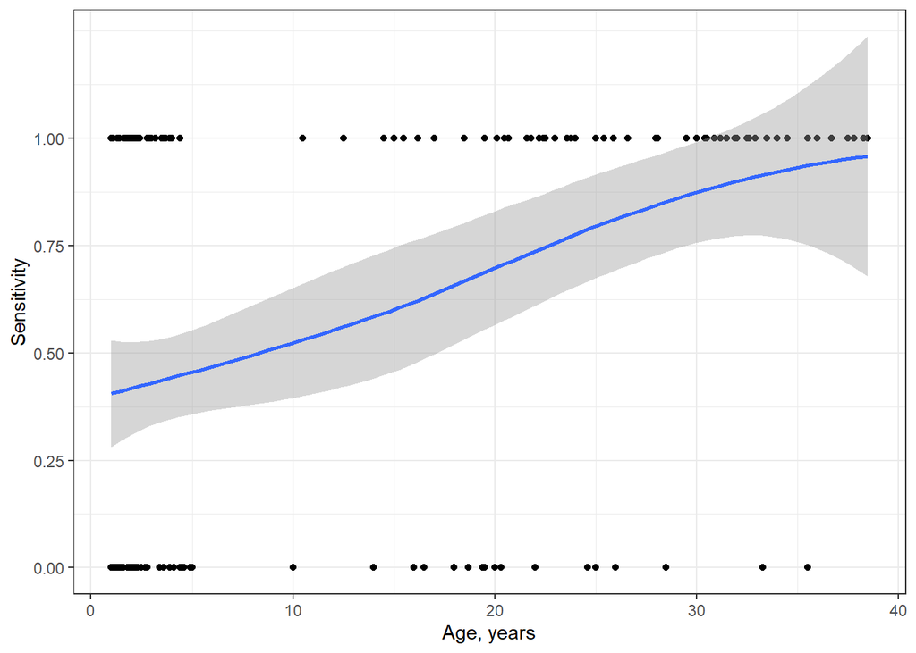

```r
ggplot(qftp_pos, aes(age, as.numeric(qia_01))) +
  geom_point() +
  geom_smooth(span=1) +
    theme_bw() +
  ylim(0,1) +
  scale_y_continuous(name="Sensitivity", breaks=seq(0,1,0.25))+
  labs(x = "Age, years")
```

Linear is visually reasonable (clearly will fail at extremes)

```r
sens_glm_age_cat <- glm(qia_01 ~ age_cat, data = qftp_pos, family = binomial)
summary(sens_glm_age_cat)
```

```
##
## Call:
## glm(formula = qia_01 ~ age_cat, family = binomial, data = qftp_pos)
##
## Deviance Residuals:
##     Min       1Q   Median       3Q      Max
## -1.9728  -1.0480   0.5553   1.0258   1.3126
##
## Coefficients:
##                    Estimate Std. Error z value Pr(>|z|)
## (Intercept)         -0.3124     0.2403  -1.300    0.194
## age_cat10-19 years   0.6801     0.4957   1.372    0.170
## age_cat20-40 years   2.1041     0.4328   4.861 1.17e-06 ***
## ---
## Signif. codes:  0 '***' 0.001 '**' 0.01 '*' 0.05 '.' 0.1 ' ' 1
##
## (Dispersion parameter for binomial family taken to be 1)
##
##     Null deviance: 206.91  on 155  degrees of freedom
## Residual deviance: 178.16  on 153  degrees of freedom
## AIC: 184.16
##
## Number of Fisher Scoring iterations: 4
```

What if age instead modelled continously?

```r
sens_glm_age_cont <- glm(qia_01 ~ age, data = qftp_pos, family = binomial)
summary(sens_glm_age_cont)
```

```
##
## Call:
## glm(formula = qia_01 ~ age, family = binomial, data = qftp_pos)
##
## Deviance Residuals:
##     Min       1Q   Median       3Q      Max
## -2.1764  -1.0169   0.5114   0.8611   1.3822
##
## Coefficients:
##             Estimate Std. Error z value Pr(>|z|)
## (Intercept) -0.54889    0.25873  -2.121   0.0339 *
## age          0.07941    0.01627   4.882 1.05e-06 ***
## ---
## Signif. codes:  0 '***' 0.001 '**' 0.01 '*' 0.05 '.' 0.1 ' ' 1
##
## (Dispersion parameter for binomial family taken to be 1)
##
##     Null deviance: 206.91  on 155  degrees of freedom
## Residual deviance: 177.53  on 154  degrees of freedom
## AIC: 181.53
##
## Number of Fisher Scoring iterations: 4
```

AIC is actually lower with continuous age.  
However for descriptive purposes for manuscript (particularly as there is a “missing” age category) it may be most logical to categorise - especially if relationship with specificity is not as clear.

```r
exp(cbind(OR = coef(sens_glm_age_cont), confint(sens_glm_age_cont)))
```

```
##                    OR     2.5 %    97.5 %
## (Intercept) 0.5775931 0.3446228 0.9541177
## age         1.0826478 1.0501505 1.1196508
```

#### B. Specificity

How does specificity relate to age?

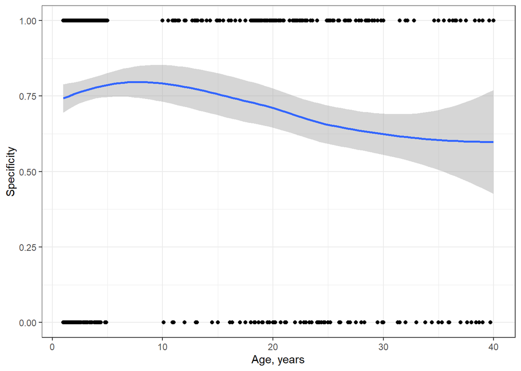

```r
ggplot(qftp_neg, aes(age, 1-as.numeric(qia_01))) +
  geom_point() +
  geom_smooth(span=1) +
  theme_bw() +
  labs(x = "Age, years",
       y = "Specificity")
```

Less strongly correlated; linear not as good. Note flipped axes - we are seeing specificity DECREASE with age

```r
spec_glm_age_cat <- glm(qia_01 ~ age_cat, data = qftp_neg, family = binomial)
summary(spec_glm_age_cat)
```

```
##
## Call:
## glm(formula = qia_01 ~ age_cat, family = binomial, data = qftp_neg)
##
## Deviance Residuals:
##     Min       1Q   Median       3Q      Max
## -0.9421  -0.7281  -0.7281   1.4326   1.7073
##
## Coefficients:
##                    Estimate Std. Error z value Pr(>|z|)
## (Intercept)        -1.19243    0.10336 -11.536  < 2e-16 ***
## age_cat10-19 years  0.09382    0.25302   0.371  0.71079
## age_cat20-40 years  0.61004    0.18927   3.223  0.00127 **
## ---
## Signif. codes:  0 '***' 0.001 '**' 0.01 '*' 0.05 '.' 0.1 ' ' 1
##
## (Dispersion parameter for binomial family taken to be 1)
##
##     Null deviance: 917.16  on 796  degrees of freedom
## Residual deviance: 906.94  on 794  degrees of freedom
## AIC: 912.94
##
## Number of Fisher Scoring iterations: 4
```

```r
spec_glm_age_cont <- glm(qia_01 ~ age, data = qftp_neg, family = binomial)
summary(spec_glm_age_cont)
```

```
##
## Call:
## glm(formula = qia_01 ~ age, family = binomial, data = qftp_neg)
##
## Deviance Residuals:
##     Min       1Q   Median       3Q      Max
## -1.0168  -0.7415  -0.7241   1.3854   1.7255
##
## Coefficients:
##              Estimate Std. Error z value Pr(>|z|)
## (Intercept) -1.254473   0.111077 -11.294  < 2e-16 ***
## age          0.021606   0.007078   3.053  0.00227 **
## ---
## Signif. codes:  0 '***' 0.001 '**' 0.01 '*' 0.05 '.' 0.1 ' ' 1
##
## (Dispersion parameter for binomial family taken to be 1)
##
##     Null deviance: 917.16  on 796  degrees of freedom
## Residual deviance: 908.05  on 795  degrees of freedom
## AIC: 912.05
##
## Number of Fisher Scoring iterations: 4
```

Marginally lower AIC with continuous age, but again close, and appears less linear visually

### ii. By other CoVs

- Some other CoVs only tested in certain age groups
- E.g. MUAC / HIV exposure / BCG in U5s
- HIV very uncommon in U20s

Define QFT Pos and Neg subgroups by age

```r
qftp_pos_u5 <- igra %>% filter(qftp_bin == "QFTP+") %>% filter(age<=5)
qftp_pos_o19 <- igra %>% filter(qftp_bin == "QFTP+") %>% filter(age>=20)
qftp_neg_u5 <- igra %>% filter(qftp_bin == "QFTP-") %>% filter(age<=5)
qftp_neg_o19 <- igra %>% filter(qftp_bin == "QFTP-") %>% filter(age>=20)
```

#### A. Sensitivity and specificity by HIV status

```r
sens_glm_hiv <- glm(qia_01 ~ hivstatus_binary, data = qftp_pos_o19, family = binomial)
summary(sens_glm_hiv)
```

```
##
## Call:
## glm(formula = qia_01 ~ hivstatus_binary, family = binomial, data = qftp_pos_o19)
##
## Deviance Residuals:
##     Min       1Q   Median       3Q      Max
## -2.0393   0.5387   0.5607   0.5607   0.5607
##
## Coefficients:
##                              Estimate Std. Error z value Pr(>|z|)
## (Intercept)                    1.7707     0.3825   4.630 3.66e-06 ***
## hivstatus_binaryHIV Positive   0.1752     1.1354   0.154    0.877
## ---
## Signif. codes:  0 '***' 0.001 '**' 0.01 '*' 0.05 '.' 0.1 ' ' 1
##
## (Dispersion parameter for binomial family taken to be 1)
##
##     Null deviance: 51.675  on 62  degrees of freedom
## Residual deviance: 51.650  on 61  degrees of freedom
## AIC: 55.65
##
## Number of Fisher Scoring iterations: 4
```

```r
spec_glm_hiv <- glm(qia_01 ~ hivstatus_binary, data = qftp_neg_o19, family = binomial)
summary(spec_glm_hiv)
```

```
##
## Call:
## glm(formula = qia_01 ~ hivstatus_binary, family = binomial, data = qftp_neg_o19)
##
## Deviance Residuals:
##     Min       1Q   Median       3Q      Max
## -1.2278  -0.9112  -0.9112   1.4694   1.4694
##
## Coefficients:
##                              Estimate Std. Error z value Pr(>|z|)
## (Intercept)                   -0.6644     0.1690  -3.931 8.48e-05 ***
## hivstatus_binaryHIV Positive   0.7822     0.5145   1.520    0.128
## ---
## Signif. codes:  0 '***' 0.001 '**' 0.01 '*' 0.05 '.' 0.1 ' ' 1
##
## (Dispersion parameter for binomial family taken to be 1)
##
##     Null deviance: 225.76  on 172  degrees of freedom
## Residual deviance: 223.46  on 171  degrees of freedom
## AIC: 227.46
##
## Number of Fisher Scoring iterations: 4
```

#### B. Sensitivity and specificity by HIV exposure status

```r
sens_glm_hivexp <- glm(qia_01 ~ hivexp_bin, data = qftp_pos_u5, family = binomial)
summary(sens_glm_hivexp)
```

```
##
## Call:
## glm(formula = qia_01 ~ hivexp_bin, family = binomial, data = qftp_pos_u5)
##
## Deviance Residuals:
##    Min      1Q  Median      3Q     Max
## -1.121  -1.028  -1.028   1.334   1.334
##
## Coefficients:
##                         Estimate Std. Error z value Pr(>|z|)
## (Intercept)              -0.1335     0.5175  -0.258    0.796
## hivexp_binHIV Unexposed  -0.2275     0.5845  -0.389    0.697
##
## (Dispersion parameter for binomial family taken to be 1)
##
##     Null deviance: 96.716  on 70  degrees of freedom
## Residual deviance: 96.565  on 69  degrees of freedom
## AIC: 100.56
##
## Number of Fisher Scoring iterations: 4
```

```r
spec_glm_hivexp <- glm(qia_01 ~ hivexp_bin, data = qftp_neg_u5, family = binomial)
summary(spec_glm_hivexp)
```

```
##
## Call:
## glm(formula = qia_01 ~ hivexp_bin, family = binomial, data = qftp_neg_u5)
##
## Deviance Residuals:
##     Min       1Q   Median       3Q      Max
## -0.7358  -0.7358  -0.7358  -0.7002   1.7470
##
## Coefficients:
##                         Estimate Std. Error z value Pr(>|z|)
## (Intercept)              -1.2809     0.2261  -5.666 1.46e-08 ***
## hivexp_binHIV Unexposed   0.1126     0.2542   0.443    0.658
## ---
## Signif. codes:  0 '***' 0.001 '**' 0.01 '*' 0.05 '.' 0.1 ' ' 1
##
## (Dispersion parameter for binomial family taken to be 1)
##
##     Null deviance: 568.71  on 523  degrees of freedom
## Residual deviance: 568.52  on 522  degrees of freedom
## AIC: 572.52
##
## Number of Fisher Scoring iterations: 4
```

#### C. Sensitivity and specificity by MUAC

How does sensitivity relate to MUAC?

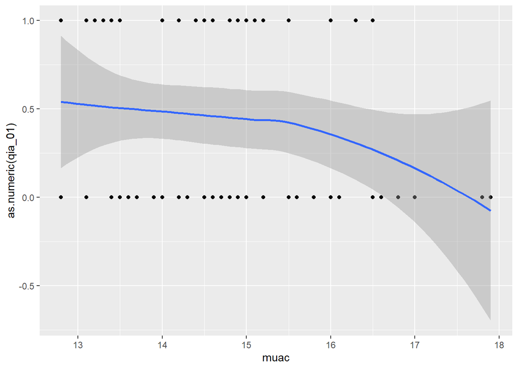

```r
ggplot(qftp_pos_u5, aes(muac, as.numeric(qia_01))) +
  geom_point() +
  geom_smooth(span=1)
```

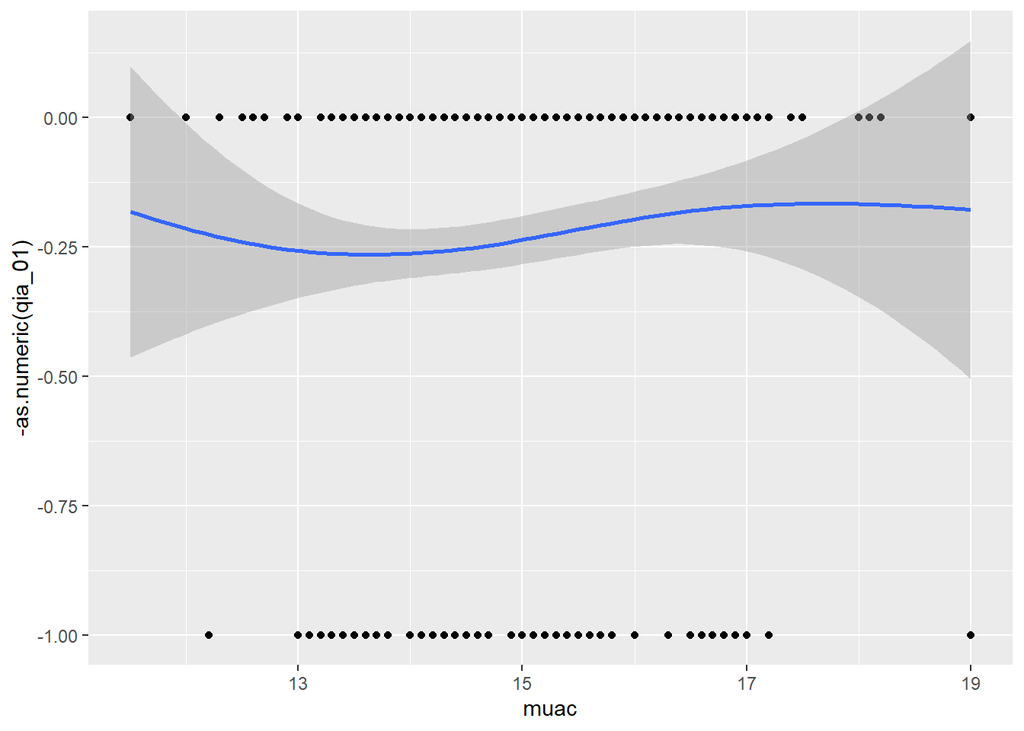

```r
ggplot(qftp_neg_u5, aes(muac, -as.numeric(qia_01))) +
  geom_point() +
  geom_smooth(span=1)
```

No clear relationship, however given MUAC conventionally categorised:

```r
sens_glm_muac <- glm(qia_01 ~ muac_bin, data = qftp_pos_u5, family = binomial)
summary(sens_glm_muac)
```

```
##
## Call:
## glm(formula = qia_01 ~ muac_bin, family = binomial, data = qftp_pos_u5)
##
## Deviance Residuals:
##    Min      1Q  Median      3Q     Max
## -1.256  -1.011  -1.011   1.354   1.354
##
## Coefficients:
##                Estimate Std. Error z value Pr(>|z|)
## (Intercept)      0.1823     0.6055   0.301    0.763
## muac_binNormal  -0.5878     0.6604  -0.890    0.373
##
## (Dispersion parameter for binomial family taken to be 1)
##
##     Null deviance: 96.716  on 70  degrees of freedom
## Residual deviance: 95.920  on 69  degrees of freedom
## AIC: 99.92
##
## Number of Fisher Scoring iterations: 4
```

```r
spec_glm_muac <- glm(qia_01 ~ muac_bin, data = qftp_neg_u5, family = binomial)
summary(spec_glm_muac)
```

```
##
## Call:
## glm(formula = qia_01 ~ muac_bin, family = binomial, data = qftp_neg_u5)
##
## Deviance Residuals:
##     Min       1Q   Median       3Q      Max
## -0.8257  -0.7186  -0.7186  -0.7186   1.7207
##
## Coefficients:
##                Estimate Std. Error z value Pr(>|z|)
## (Intercept)     -0.9008     0.3289  -2.739  0.00617 **
## muac_binNormal  -0.3214     0.3465  -0.928  0.35366
## ---
## Signif. codes:  0 '***' 0.001 '**' 0.01 '*' 0.05 '.' 0.1 ' ' 1
##
## (Dispersion parameter for binomial family taken to be 1)
##
##     Null deviance: 568.71  on 523  degrees of freedom
## Residual deviance: 567.89  on 522  degrees of freedom
## AIC: 571.89
##
## Number of Fisher Scoring iterations: 4
```

## 5. Possible sources of misclassification

### A. Why do indeterminates occur?

```r
igra %>% filter(QFTP_result == "Indeterminate") %>% tabyl( indet_reason, age_cat) %>% adorn_totals("col")  %>% adorn_percentages("col") %>%
  adorn_pct_formatting(rounding = "half up", digits = 0)
```

```
##  indet_reason 1-4 years 10-19 years 20-40 years Total
##      High nil        4%         13%         50%    8%
##   Low mitogen       96%         88%         50%   92%
```

Mostly due to low mitogen, especially in the young kids

```r
igra %>% filter(QFTP_result == "Indeterminate") %>% tabyl(QIAreach_QFT, age_cat, indet_reason)%>% adorn_totals("col") %>% adorn_percentages("col") %>%
  adorn_pct_formatting(rounding = "half up", digits = 0)
```

```
## $`High nil`
##  QIAreach_QFT 1-4 years 10-19 years 20-40 years Total
##      Negative       67%        100%         25%   50%
##      Positive       33%          0%         75%   50%
##
## $`Low mitogen`
##  QIAreach_QFT 1-4 years 10-19 years 20-40 years Total
##      Negative       78%         71%         25%   75%
##      Positive       22%         29%         75%   25%
```

### B. What happens if indeterminates are reclassified?

#### i. To positive

```r
igra <- igra %>%
  mutate(qftp_reclassify_indpos = case_when(
    QFTP_result == "Negative" ~ 0,
    QFTP_result == "Positive" ~ 1,
    QFTP_result == "Indeterminate" ~ 1),
        qftp_reclassify_indpos = factor(qftp_reclassify_indpos, levels=c(1,0), labels = c("Pos or Ind", "Neg")))

reclassify_indpos_acc <- acc_func(data=igra, truth="qftp_reclassify_indpos", test="qia_01", strata = all) %>%
  bind_rows(acc_func(data=igra, truth="qftp_reclassify_indpos", test="qia_01", strata = age_cat)) %>%
  bind_rows(igra %>% filter(age>=20) %>% acc_func(truth="qftp_reclassify_indpos", test="qia_01", strata = hivstatus_binary))  %>%
    t() %>% as.data.frame() %>% row_to_names(3) %>% tibble::rownames_to_column() %>%
  dplyr::rename(All = all)
```

#### ii. To negative

```r
igra <- igra %>%
  mutate(qftp_reclassify_indneg = case_when(
    QFTP_result == "Negative" ~ 0,
    QFTP_result == "Positive" ~ 1,
    QFTP_result == "Indeterminate" ~ 0),
        qftp_reclassify_indneg = factor(qftp_reclassify_indneg, levels=c(1,0), labels = c("Pos or Ind", "Neg")))

reclassify_indneg_acc <- acc_func(data=igra, truth="qftp_reclassify_indneg", test="qia_01", strata = all) %>%
  bind_rows(acc_func(data=igra, truth="qftp_reclassify_indneg", test="qia_01", strata = age_cat)) %>%
  bind_rows(igra %>% filter(age>=20) %>% acc_func(truth="qftp_reclassify_indneg", test="qia_01", strata = hivstatus_binary))  %>%
    t() %>% as.data.frame() %>% row_to_names(3) %>% tibble::rownames_to_column() %>%
  dplyr::rename(All = all)
reclassify_indneg_acc
```

```
##            rowname                 All           1-4 years         10-19 years
## 1                n                1049                 675                 130
## 2      Sensitivity       38% (30%-46%)       58% (45%-69%)       41% (21%-64%)
## 3      Specificity       26% (23%-29%)       23% (20%-27%)       25% (17%-34%)
## 4              PPV         8% (6%-10%)         8% (6%-11%)        10% (5%-18%)
## 5              NPV       71% (66%-76%)       82% (76%-88%)       68% (51%-81%)
## 6            Kappa -0.14 (-0.18--0.11) -0.05 (-0.08--0.02) -0.15 (-0.25--0.06)
## 7          age_cat                <NA>           1-4 years         10-19 years
## 8 hivstatus_binary                <NA>                <NA>                <NA>
##           20-40 years       HIV Positive HIV Negative or Unknown
## 1                 244                 25                     219
## 2        14% (7%-25%)       12% (0%-53%)            15% (6%-27%)
## 3       38% (30%-45%)      53% (28%-77%)           36% (29%-44%)
## 4         7% (3%-14%)       11% (0%-48%)             7% (3%-13%)
## 5       56% (46%-65%)      56% (30%-80%)           56% (46%-65%)
## 6 -0.37 (-0.48--0.26) -0.33 (-0.72-0.06)     -0.37 (-0.48--0.25)
## 7         20-40 years               <NA>                    <NA>
## 8                <NA>       HIV Positive HIV Negative or Unknown
```

### B. Results which are positive only on TB1

```r
igra %>% filter(QFTP_result == "Positive") %>% tabyl(tb1_tb2, age_cat) %>%
  adorn_totals("col")%>%
  adorn_percentages("col") %>%
    adorn_pct_formatting() %>%
  adorn_ns(position = "front")
```

```
##             tb1_tb2  1-4 years 10-19 years 20-40 years      Total
##  TB1 & TB2 Positive 22 (31.0%)  15 (68.2%)  50 (79.4%) 87 (55.8%)
##   TB1 only positive 20 (28.2%)   2  (9.1%)   8 (12.7%) 30 (19.2%)
##   TB2 only positive 29 (40.8%)   5 (22.7%)   5  (7.9%) 39 (25.0%)
```

- Many of the young kids have positive results only on TB1 or TB2, not both
- Lower percentage in older age groups

Of those which are positive only on TB1, what is the QIAreach result?

```r
igra %>% filter(QFTP_result == "Positive") %>%
  filter(tb1_tb2=="TB1 only positive") %>%
  tabyl(QIAreach_QFT,age_cat)%>%
  adorn_totals("col")%>%
  adorn_percentages("col") %>%
    adorn_pct_formatting() %>%
  adorn_ns(position = "front")
```

```
##  QIAreach_QFT  1-4 years 10-19 years 20-40 years      Total
##      Negative 13 (65.0%)  2 (100.0%)   3 (37.5%) 18 (60.0%)
##      Positive  7 (35.0%)  0   (0.0%)   5 (62.5%) 12 (40.0%)
```

So of 59 “false negative” results (positive QFT-Plus, negative QIAreach), potentially 18/59 (30.5%) explained by a TB1-only positive result.

### C. Low level positives on QFT-Plus

```r
igra %>% filter(QFTP_result == "Positive") %>% tabyl(QIAreach_QFT, igra_0.7, age_cat)
```

```
## $`1-4 years`
##  QIAreach_QFT IGRA positive at 0.35-0.7 IGRA positive at 0.7
##      Negative                        12                   29
##      Positive                         8                   22
##
## $`10-19 years`
##  QIAreach_QFT IGRA positive at 0.35-0.7 IGRA positive at 0.7
##      Negative                         3                    6
##      Positive                         0                   13
##
## $`20-40 years`
##  QIAreach_QFT IGRA positive at 0.35-0.7 IGRA positive at 0.7
##      Negative                         5                    4
##      Positive                         5                   49
```

### D. QFT-Plus esults which have a TB1/TB2 above the positive threshold, but then are once nil subtracted

```r
igra %>% filter(QFTP_result == "Negative") %>% tabyl(nil_adjusted, age_cat) %>%
  adorn_totals("col")%>%
  adorn_percentages("col") %>%
    adorn_pct_formatting() %>%
  adorn_ns(position = "front")
```

```
##             nil_adjusted   1-4 years 10-19 years 20-40 years       Total
##  Negative after adjusted  29  (5.5%)   4  (4.0%)  16  (9.2%)  49  (6.1%)
##      Negative unadjusted 495 (94.5%)  96 (96.0%) 157 (90.8%) 748 (93.9%)
```

```r
igra %>% filter(QFTP_result == "Negative") %>%
  filter(nil_adjusted=="Negative after adjusted") %>%
  tabyl(QIAreach_QFT,age_cat)%>%
  adorn_totals("col")%>%
  adorn_percentages("col") %>%
    adorn_pct_formatting() %>%
  adorn_ns(position = "front")
```

```
##  QIAreach_QFT  1-4 years 10-19 years 20-40 years      Total
##      Negative 11 (37.9%)   2 (50.0%)   4 (25.0%) 17 (34.7%)
##      Positive 18 (62.1%)   2 (50.0%)  12 (75.0%) 32 (65.3%)
```

49 results with a high TB1 or TB2 but which when adjusted would be below the cut-off (6.1% of total) - most of these (32, 65%) are called as positive by QIAreach

## 6. Exploring quantitative QIAreach values as sources of misclassification

```r
igra %>%
  filter(QFTP_result !="Indeterminate") %>% tabyl(QIAreach_cat, QFTP_result) %>%
 adorn_totals("col")%>%
  adorn_percentages("row") %>%
    adorn_pct_formatting() %>%
  adorn_ns(position = "front") # %>% View() #write.xlsx("SuppTab_ttp20.xlsx")
```

```
##                      QIAreach_cat     Negative   Positive Indeterminate
##                          Negative 588  (90.9%) 59  (9.1%)      0 (0.0%)
##     Strong positive, TTP <20 mins  75  (50.3%) 74 (49.7%)      0 (0.0%)
##  Borderline positive, TTP 20 mins 133  (85.3%) 23 (14.7%)      0 (0.0%)
##                              <NA>   1 (100.0%)  0  (0.0%)      0 (0.0%)
##         Total
##  647 (100.0%)
##  149 (100.0%)
##  156 (100.0%)
##    1 (100.0%)
```

74/149 “strong positive” QIAreach have a positive QFTP = 50% 23/156 “weak positive” QIAreach have a positive QFTP = 15% 59/647 “negative” QIAreach have a posiive QFTP = 9%

```r
igra %>% filter(concordance_status == "False Positive") %>%
  tabyl(QIAreach_cat)
```

```
##                      QIAreach_cat   n     percent valid_percent
##                          Negative   0 0.000000000     0.0000000
##     Strong positive, TTP <20 mins  75 0.358851675     0.3605769
##  Borderline positive, TTP 20 mins 133 0.636363636     0.6394231
##                              <NA>   1 0.004784689            NA
```

Reclassifying “weak positives” as negative

```r
igra <- igra %>%
  mutate(qia_reclassify = case_when(QIAreach_cat == "Strong positive, TTP <20 mins" ~ 1,
                                    QIAreach_cat == "Negative" ~ 0,
                                    QIAreach_cat == "Borderline positive, TTP 20 mins" ~ 0),
  qia_reclassify = factor(qia_reclassify, levels=c(1,0), labels=c("Strong+", "Weak+or-")))

reclassify_acc <- acc_func(data=igra, truth="qftp_bin", test="qia_reclassify", strata = all) %>%
  bind_rows(acc_func(data=igra, truth="qftp_bin", test="qia_reclassify", strata = age_cat)) %>%
  bind_rows(igra %>% filter(age>=20) %>% acc_func(truth="qftp_bin", test="qia_reclassify", strata = hivstatus_binary))  %>%
    t() %>% as.data.frame() %>% row_to_names(3) %>% tibble::rownames_to_column() %>%
  dplyr::rename(All = all)
```

Exploring QFTP values for each

```r
igra %>%  filter(QIAreach_cat != "NA_") %>% tabyl(igra_0.7, QIAreach_cat) %>% adorn_totals("col")
```

```
##                   igra_0.7 Negative Strong positive, TTP <20 mins
##  IGRA positive at 0.35-0.7       20                             7
##       IGRA positive at 0.7       39                            67
##              Indeterminate       70                             7
##                   Negative      588                            75
##  Borderline positive, TTP 20 mins Total
##                                 6    33
##                                17   123
##                                19    96
##                               133   796
```

```r
igra %>% tabyl(igra_0.7, QIAreach_QFT) %>% adorn_totals("col")
```

```
##                   igra_0.7 Negative Positive Total
##  IGRA positive at 0.35-0.7       20       13    33
##       IGRA positive at 0.7       39       84   123
##              Indeterminate       70       26    96
##                   Negative      588      209   797
```

84/123 “strong” positive IGRAs are positive by QIAreach = 68% 13/33 “weak” positive IGRAs are positive by QIAreach = 39% 209/797 negative IGRAs are positive by QIAreach = 26%

## 7. Comparing actual quantitative values

Removing indeterminate values

```r
igra_noind <- igra %>% filter(QFTP_result !="Indeterminate")
```

```r
unadjusted_tb2_graph_crude<-
  igra_noind %>%
  filter(QIAreach_QFT=="Positive") %>%
ggplot(aes(x = QFTP_TB2, y = QIAreach_TTP_min)) +
  geom_point(alpha=0.7,
             aes(col=QFTP_result)) +
  theme_bw() +
  theme(legend.position = "nil" ) +
  facet_grid(.~age_cat) +
  labs(y=bquote("QIAreach: TTP(min)"),
         x="",
        title = "a",
        # x="QFT-Plus: Unadjusted TB2 (IU/mL)",
       col="QFT-Plus result") +
  ylim(0,20)
unadjusted_tb2_graph_crude<- unadjusted_tb2_graph_crude +
  geom_smooth(span=1, linewidth = 0.75, colour = "slategray", alpha = 0.3)
```

Alternatively, plotting 1/TTP rather than TTP  
- a priori, we might expect the CONCENTRATION of IFN-g to be correlated with the RATE of QIAReach becoming positive (i.e. 1/TTP)

```r
unadjusted_tb2_graph_inv<-
  igra_noind %>%
  filter(QIAreach_QFT=="Positive") %>%
ggplot(aes(x = QFTP_TB2, y = ttp_inv_min)) +
  geom_point(alpha=0.7,
             aes(col=QFTP_result)) +
  theme_bw() +
  theme(legend.position = "bottom") +
  facet_grid(.~age_cat) +
  labs(y=bquote("QIAreach: 1/TTP(" ~min^-1~")"),
         x="QFT-Plus: Unadjusted TB2 (IU/mL)",
       col="QFT-Plus result",
        title = "b")
unadjusted_tb2_graph_inv<-unadjusted_tb2_graph_inv + geom_smooth(span=1, colour = "slategray", linewidth = 0.75, alpha = 0.3)
```

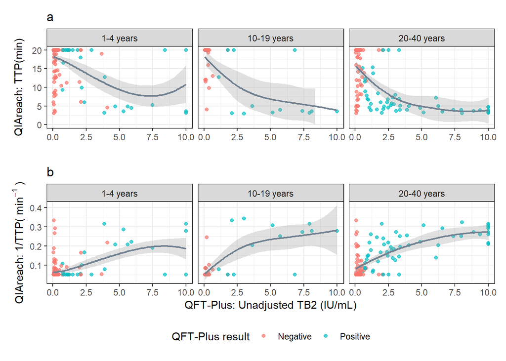

```r
unadjusted_tb2_graph_crude /
  unadjusted_tb2_graph_inv
```

```r
ggsave("Fig1_dual.png")
```

Neither of these appear linear in their relationship. Overall data (no age categorisation) for completeness.

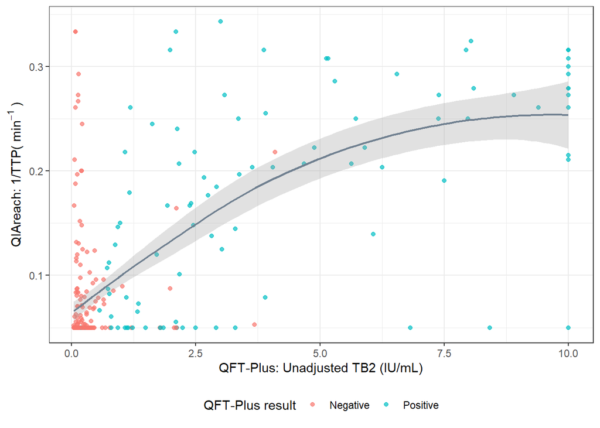

```r
unadjusted_tb2_graph_inv_all <- igra_noind %>%
  filter(QIAreach_QFT=="Positive") %>%
ggplot(aes(x = QFTP_TB2, y = ttp_inv_min)) +
  geom_point(alpha=0.7,
             aes(col=QFTP_result)) +
  theme_bw() +
  theme(legend.position = "bottom") +
  labs(y=bquote("QIAreach: 1/TTP(" ~min^-1~")"),
         x="QFT-Plus: Unadjusted TB2 (IU/mL)",
       col="QFT-Plus result")
unadjusted_tb2_graph_inv_all +
  geom_smooth(span=1, colour = "slategray", linewidth = 0.75, alpha = 0.3)
```

## 8. Measurement of correlation

- Aim to quantify the degree of correlation, by age-group
- Linear regression / R-squared not appropriate, as definitely non-linear
- We can therefore use a Spearman rank coefficient instead (requires only monotonic relationship)
- Note that transforming - i.e. taking 1/TTP - doesn’t make any difference to the outcome of the statistical test as it’s a ranked test

```r
corr_all <-igra_noind %>%
  filter(QIAreach_QFT == "Positive")
corr_u5 <- igra_noind %>%
  filter(QIAreach_QFT == "Positive") %>% filter(age_cat == "1-4 years")
corr_10 <- igra_noind %>%
  filter(QIAreach_QFT == "Positive") %>% filter(age_cat == "10-19 years")
corr_20 <- igra_noind %>%
  filter(QIAreach_QFT == "Positive") %>% filter(age_cat == "20-40 years")


cor.test(corr_u5$QFTP_TB2, corr_u5$QIAreach_TTP_s, method = "spearman") %>% tidy() %>% mutate(age_cat = "1-5 years") %>%
  bind_rows(
cor.test(corr_10$QFTP_TB2, corr_10$QIAreach_TTP_s, method = "spearman") %>% tidy() %>% mutate(age_cat = "10-19 years")) %>%
  bind_rows(
cor.test(corr_20$QFTP_TB2, corr_20$QIAreach_TTP_s, method = "spearman") %>% tidy() %>% mutate(age_cat = "20-40 years")) %>%
mutate(rho = estimate) %>% dplyr::select(age_cat, rho, statistic, p.value)
```

```
## # A tibble: 3 × 4
##   age_cat        rho statistic  p.value
##   <chr>        <dbl>     <dbl>    <dbl>
## 1 1-5 years   -0.257   721128. 1.46e- 3
## 2 10-19 years -0.588    14509. 1.05e- 4
## 3 20-40 years -0.596   415261. 1.62e-12
```

## 9. Hurdle categorical model

Putting this all into one model - Incorporating negatives in a hurdle distribution  
- Dividing TTP into ordinal categories of 2 minutes - for interpretability and visualisation, and to allow a separate ordinal category for exactly 20 minutes

```r
igra_noind <- igra_noind %>%
  mutate(
    ttp_cat2 = 2*floor(QIAreach_TTP_s/120)) %>% #Divide ttp into 2-minute brackets
  mutate(
  ttp_cat2 = factor(
    case_when(QIAreach_QFT == "Negative"~ 0, #Create hurdle
                                   TRUE ~ ttp_cat2),
              ordered = TRUE,
              labels = c("Negative", "2 to <4", "4 to <6", "6 to <8", "8 to <10",
                                      "10 to <12", "12 to <14", "14 to <16", "16 to <18", "18 to <20", "20")))

tabyl(igra_noind$ttp_cat2)
```

```
##  igra_noind$ttp_cat2   n     percent valid_percent
##             Negative 647 0.678908709   0.679621849
##              2 to <4  32 0.033578174   0.033613445
##              4 to <6  32 0.033578174   0.033613445
##              6 to <8  15 0.015739769   0.015756303
##             8 to <10  13 0.013641133   0.013655462
##            10 to <12  12 0.012591815   0.012605042
##            12 to <14  14 0.014690451   0.014705882
##            14 to <16  12 0.012591815   0.012605042
##            16 to <18   7 0.007345226   0.007352941
##            18 to <20  12 0.012591815   0.012605042
##                   20 156 0.163693599   0.163865546
##                 <NA>   1 0.001049318            NA
```

```r
# 1 positive QIAreach is missing a TTP and theefore excluded
```

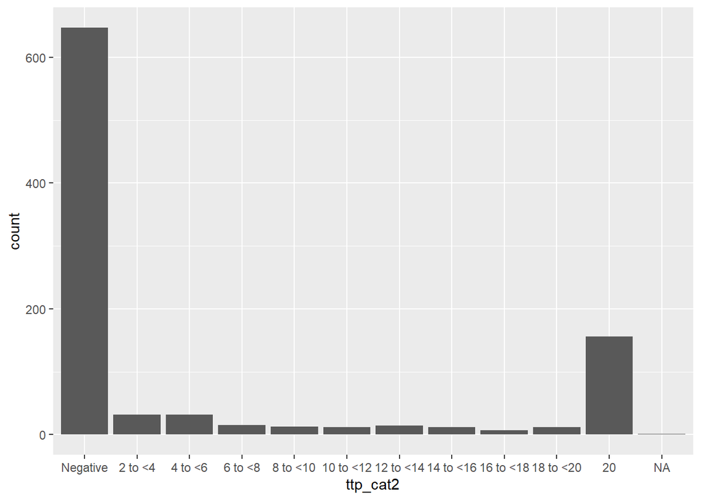

```r
igra_noind %>%
  ggplot() +
  geom_bar(aes(x=ttp_cat2))
```

Note that 0 here is negative - whereas it’s actually logically “after” 20.  
But this doesn’t matter for purposes of this model. We later designate 0 as our hurdle - and clearing the hurdle is an independent process to the second component

```r
set.seed(279)
m1 <- brm(
  data = igra_noind,
  family = hurdle_cumulative(link="cauchit"),
  bf(ttp_cat2 ~ QFTP_TB2*age_cat,
  hu ~ QFTP_TB2*age_cat),
  cores = 4,
  chains = 4)
```

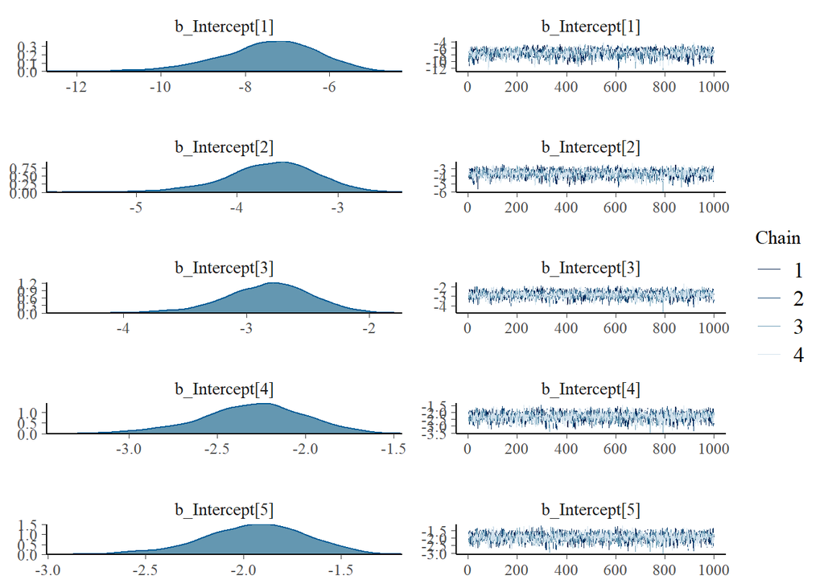

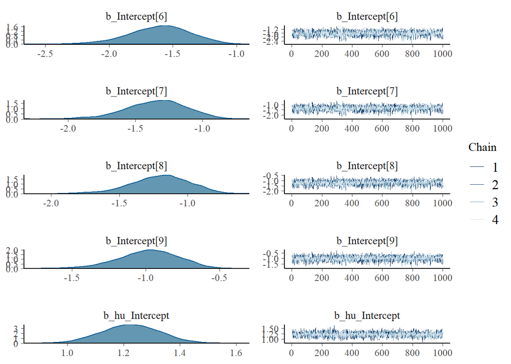

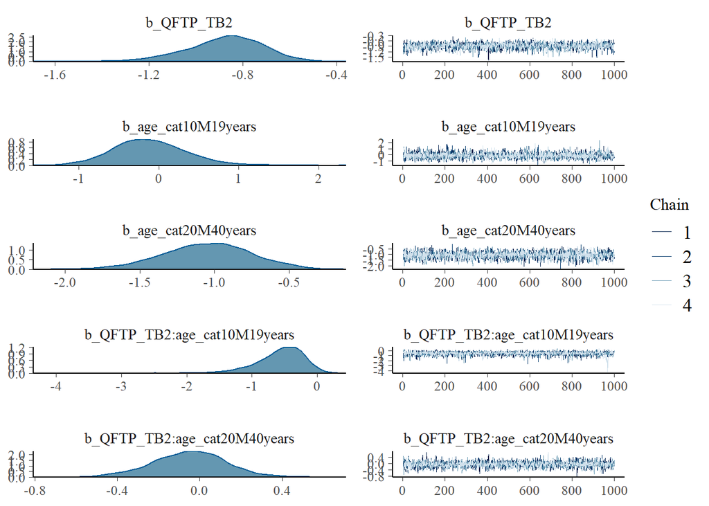

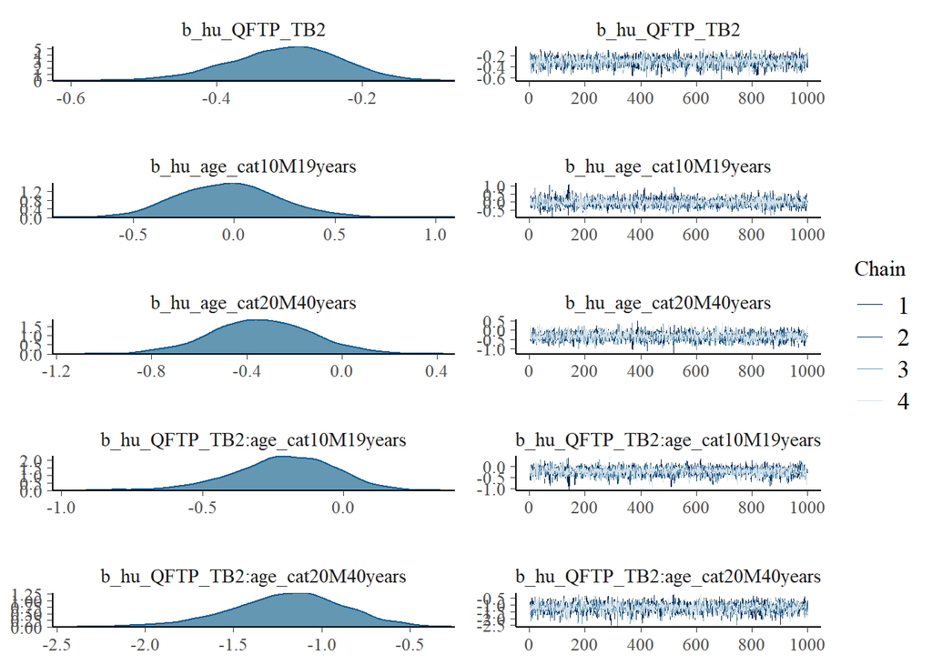

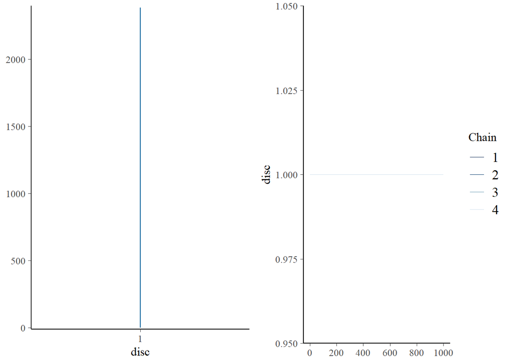

```r
plot(m1)
```

```r
summary(m1)
```

```
##  Family: hurdle_cumulative
##   Links: mu = cauchit; hu = logit; disc = identity
## Formula: ttp_cat2 ~ QFTP_TB2 * age_cat
##          hu ~ QFTP_TB2 * age_cat
##    Data: igra_noind (Number of observations: 952)
##   Draws: 4 chains, each with iter = 2000; warmup = 1000; thin = 1;
##          total post-warmup draws = 4000
##
## Population-Level Effects:
##                               Estimate Est.Error l-95% CI u-95% CI Rhat
## Intercept[1]                     -7.46      1.16   -10.00    -5.47 1.00
## Intercept[2]                     -3.66      0.45    -4.63    -2.86 1.00
## Intercept[3]                     -2.82      0.35    -3.58    -2.19 1.00
## Intercept[4]                     -2.30      0.30    -2.94    -1.75 1.00
## Intercept[5]                     -1.94      0.27    -2.52    -1.46 1.00
## Intercept[6]                     -1.60      0.24    -2.12    -1.16 1.00
## Intercept[7]                     -1.35      0.23    -1.84    -0.94 1.00
## Intercept[8]                     -1.20      0.22    -1.68    -0.81 1.00
## Intercept[9]                     -0.98      0.20    -1.42    -0.62 1.00
## hu_Intercept                      1.22      0.10     1.03     1.42 1.00
## QFTP_TB2                         -0.88      0.16    -1.23    -0.59 1.00
## age_cat10M19years                -0.11      0.46    -0.97     0.86 1.00
## age_cat20M40years                -1.05      0.29    -1.65    -0.49 1.00
## QFTP_TB2:age_cat10M19years       -0.57      0.38    -1.43     0.00 1.00
## QFTP_TB2:age_cat20M40years       -0.05      0.18    -0.41     0.29 1.00
## hu_QFTP_TB2                      -0.31      0.08    -0.47    -0.16 1.00
## hu_age_cat10M19years             -0.03      0.25    -0.49     0.48 1.00
## hu_age_cat20M40years             -0.34      0.21    -0.76     0.08 1.00
## hu_QFTP_TB2:age_cat10M19years    -0.21      0.18    -0.60     0.12 1.00
## hu_QFTP_TB2:age_cat20M40years    -1.20      0.33    -1.91    -0.59 1.00
##                               Bulk_ESS Tail_ESS
## Intercept[1]                      1414     1903
## Intercept[2]                      1949     2043
## Intercept[3]                      2323     2397
## Intercept[4]                      2657     2717
## Intercept[5]                      2883     2729
## Intercept[6]                      3131     2806
## Intercept[7]                      3243     2968
## Intercept[8]                      3331     2848
## Intercept[9]                      3550     3140
## hu_Intercept                      4712     2962
## QFTP_TB2                          1979     2329
## age_cat10M19years                 3505     2284
## age_cat20M40years                 3427     2847
## QFTP_TB2:age_cat10M19years        2780     1728
## QFTP_TB2:age_cat20M40years        3196     2750
## hu_QFTP_TB2                       3842     2663
## hu_age_cat10M19years              4412     3112
## hu_age_cat20M40years              3568     2982
## hu_QFTP_TB2:age_cat10M19years     3189     2167
## hu_QFTP_TB2:age_cat20M40years     2909     2765
##
## Family Specific Parameters:
##      Estimate Est.Error l-95% CI u-95% CI Rhat Bulk_ESS Tail_ESS
## disc     1.00      0.00     1.00     1.00   NA       NA       NA
##
## Draws were sampled using sampling(NUTS). For each parameter, Bulk_ESS
## and Tail_ESS are effective sample size measures, and Rhat is the potential
## scale reduction factor on split chains (at convergence, Rhat = 1).
```

- 9 intercepts correspond to the points of transition between categories

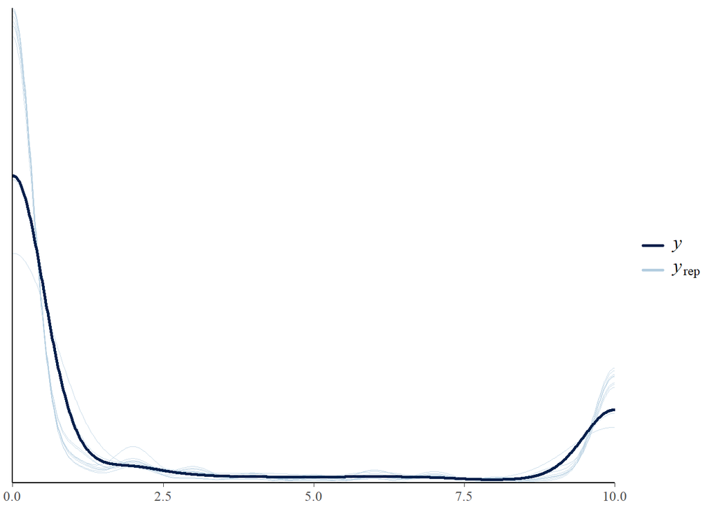

```r
pp_check(m1)
```

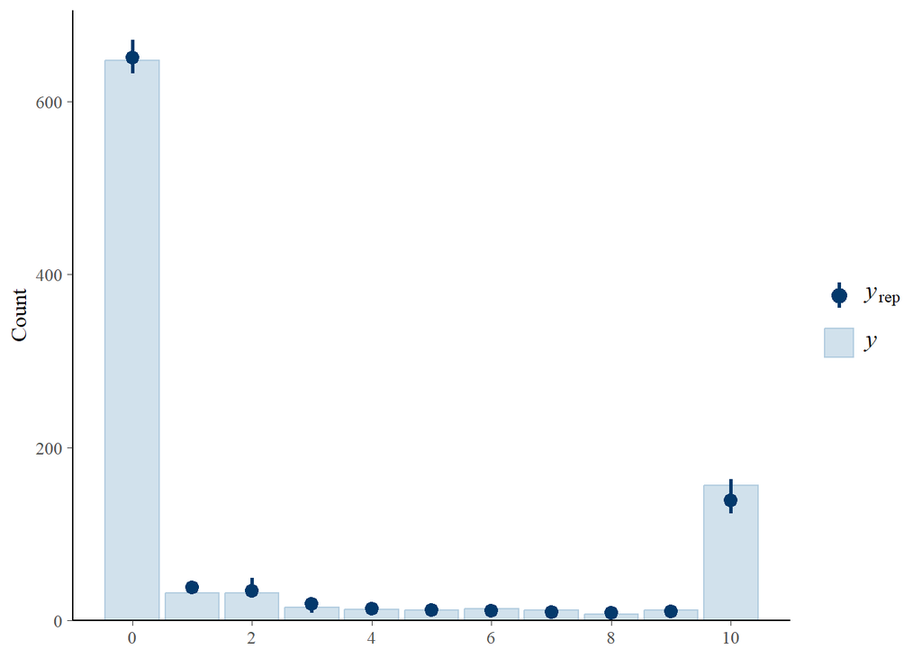

```r
pp_check(m1, type="bars")
```

```r
nd <- crossing(age_cat = unique(igra_noind$age_cat),
               QFTP_TB2 = modelr::seq_range(igra_noind$QFTP_TB2, n=20))


m1_out <- nd %>%
  add_epred_draws(m1, allow_new_levels=TRUE)

overall_outs_m1 <- m1_out %>%
  # ungroup() %>%
  # group_by(age_cat, QFTP_TB2) %>%
  mean_qi(.epred) %>%
  mutate(.category = fct_rev(fct_relevel(.category, "Negative", after=Inf)))

levels(overall_outs_m1$.category)
```

```
##  [1] "Negative"  "20"        "18 to <20" "16 to <18" "14 to <16" "12 to <14"
##  [7] "10 to <12" "8 to <10"  "6 to <8"   "4 to <6"   "2 to <4"
```

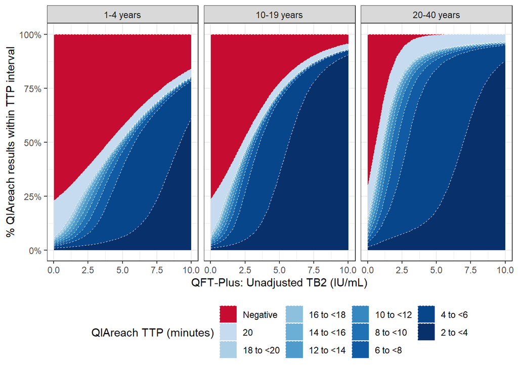

```r
nb_cols2 <- 13
myblues2 <- colorRampPalette(brewer.pal(9, "Blues"))(nb_cols2)[4:13]
myblues2_rev <-rev(myblues2)
mycolors2 <- append(myblues2, "#C60C30",after = 0)

m1_plot <- overall_outs_m1 %>%
  ggplot() +
  geom_area(aes(x=QFTP_TB2, y=.epred, fill=factor(.category)), size=.25, colour="white", linetype=2) +
  facet_grid(.~age_cat) +
  theme_bw() +
  scale_fill_manual(values = mycolors2,
                    name = "QIAreach TTP (minutes)") +
  scale_y_continuous(labels = scales::percent) +
  theme(legend.position = "bottom") +
    guides(fill = guide_legend(nrow = 3)) +
  labs(y= "% QIAreach results within TTP interval",
       x="QFT-Plus: Unadjusted TB2 (IU/mL)")

m1_plot
```

Improving the legend

```r
legend_scale <- cbind(mycolors2, levels(overall_outs_m1$.category)) %>%
  as.data.frame()
legend_scale <- legend_scale[-1,] %>%
  mutate(val = as.numeric(substr(V2, 1,2))+1)

midpoints_list <- as.list(legend_scale$val)
colours_list <- as.list(legend_scale$mycolors2)

# Plot for the color gradient legend
legend_plot <- ggplot(legend_scale, aes(x = 1, y = val, fill = val)) +
  geom_tile() +
  scale_fill_gradientn(colours = rev(colours_list), guide = "colorbar",
                         limits = c(2,20), breaks = c(5, 10, 15, 20)) +
  guides(fill = guide_colorbar(direction="horizontal",
                               reverse=TRUE)) +
    theme(legend.text = element_text(size = 10),
          legend.title = element_text(size = 12)) +
  labs(fill = "TTP of positive QIAreach results (min)")

# Print the legend plot
legend_scale<- get_legend(legend_plot)
# plot(legend_scale)
```

```r
legend_plot2<- igra_noind %>%
  mutate(qia_res= factor(qia_01, levels=c(0,1), labels=c("Negative", "Positive"))) %>%
  ggplot() +
  geom_bar(aes(x= qia_res, fill=qia_res)) +
  scale_fill_manual(values=c("#C60C30", "#4F9BCB")) +
  labs(fill = "QIAreach result") +
    theme(legend.direction="horizontal",
          legend.text = element_text(size = 10),
          legend.title = element_text(size = 12))
legend_fill<- get_legend(legend_plot2)
#plot(legend_fill)
```

Put it all together

```r
#1. Plot without legend
m1_plot_nolegend <- overall_outs_m1 %>%
  ggplot() +
  geom_area(aes(x=QFTP_TB2, y=.epred, fill=factor(.category)), size=.25, colour="white", linetype=2) +
  facet_grid(.~age_cat) +
  theme_bw() +
  scale_fill_manual(values = mycolors2,
                    name = "QIAreach TTP (minutes)") +
  scale_y_continuous(labels = scales::percent) +
  theme(legend.position = "none") +
  labs(y= "% QIAreach results within TTP interval",
       x="QFT-Plus: Unadjusted TB2 (IU/mL)")

legend_comb<- plot_grid(legend_fill, legend_scale, ncol=2)
#legend_comb
```

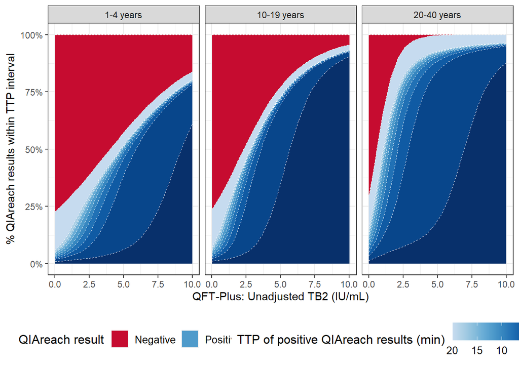

```r
comb_plot <- plot_grid(m1_plot_nolegend,legend_comb, ncol=1,
                       rel_heights = c(1, .2))
comb_plot
```

```r
ggsave("Fig2.png", width = 10, bg="white")
```

Pulling out some illustrative numbers

```r
nd_test <- crossing(age_cat = unique(igra_noind$age_cat),
               QFTP_TB2 = c(0,1,5))
nd_test
```

```
## # A tibble: 9 × 2
##   age_cat     QFTP_TB2
##   <fct>          <dbl>
## 1 1-4 years          0
## 2 1-4 years          1
## 3 1-4 years          5
## 4 10-19 years        0
## 5 10-19 years        1
## 6 10-19 years        5
## 7 20-40 years        0
## 8 20-40 years        1
## 9 20-40 years        5
```

```r
m1_out_test <- nd_test %>%
  add_epred_draws(m1, allow_new_levels=TRUE)
m1_out_test %>%
  mean_qi()
```

```
## # A tibble: 99 × 10
##    age_cat   QFTP_TB2  .row .category  .epred  .lower  .upper .width .point
##    <fct>        <dbl> <int> <fct>       <dbl>   <dbl>   <dbl>  <dbl> <chr>
##  1 1-4 years        0     1 Negative  0.772   0.736   0.806     0.95 mean
##  2 1-4 years        0     1 2 to <4   0.00988 0.00689 0.0136    0.95 mean
##  3 1-4 years        0     1 4 to <6   0.00970 0.00659 0.0134    0.95 mean
##  4 1-4 years        0     1 6 to <8   0.00540 0.00292 0.00879   0.95 mean
##  5 1-4 years        0     1 8 to <10  0.00511 0.00267 0.00861   0.95 mean
##  6 1-4 years        0     1 10 to <12 0.00481 0.00246 0.00821   0.95 mean
##  7 1-4 years        0     1 12 to <14 0.00601 0.00311 0.0101    0.95 mean
##  8 1-4 years        0     1 14 to <16 0.00602 0.00294 0.0102    0.95 mean
##  9 1-4 years        0     1 16 to <18 0.00405 0.00162 0.00776   0.95 mean
## 10 1-4 years        0     1 18 to <20 0.00731 0.00356 0.0127    0.95 mean
## # ℹ 89 more rows
## # ℹ 1 more variable: .interval <chr>
```

Recategorising output of same model (m1) to just include negative, positive at <20 mins and positive at 20 mins, to get 95% UIs

```r
m1_out_test %>%
  mutate(.category = case_when(
    .category == "Negative" ~ "Negative",
    .category == "20" ~ "20 mins", #recategorise TTP
    TRUE ~ "<20 mins")) %>%
  group_by(.row, age_cat, QFTP_TB2, .category) %>%
  summarise( #Manually performing function of mean_qi()
    .epred_mean = mean(.epred),                   # Mean prediction
    .epred_low = quantile(.epred, probs = 0.025), # 2.5% quantile (lower bound)
    .epred_high = quantile(.epred, probs = 0.975) # 97.5% quantile (upper bound)
  )
```

```
## # A tibble: 27 × 7
## # Groups:   .row, age_cat, QFTP_TB2 [9]
##     .row age_cat     QFTP_TB2 .category .epred_mean .epred_low .epred_high
##    <int> <fct>          <dbl> <chr>           <dbl>      <dbl>       <dbl>
##  1     1 1-4 years          0 20 mins       0.169      0.140        0.201
##  2     1 1-4 years          0 <20 mins      0.00648    0.00248      0.0122
##  3     1 1-4 years          0 Negative      0.772      0.736        0.806
##  4     2 1-4 years          1 20 mins       0.152      0.114        0.194
##  5     2 1-4 years          1 <20 mins      0.0148     0.00646      0.0264
##  6     2 1-4 years          1 Negative      0.714      0.670        0.754
##  7     3 1-4 years          5 20 mins       0.0545     0.0314       0.0873
##  8     3 1-4 years          5 <20 mins      0.0576     0.00141      0.386
##  9     3 1-4 years          5 Negative      0.427      0.258        0.588
## 10     4 10-19 years        0 20 mins       0.167      0.107        0.239
## # ℹ 17 more rows
```